# QTM 151 - Quiz 2

## Try to submit as an HTML file

Print your Emory code below

```python
# Write your answer here
print ("2549668")
```

```
2549668
```

This quiz is open book

- You can use the lecture notes and Google
- You will get partial credit for attempting the questions
- To get full credit, the code should run as intended
- You should NOT communicate with other students

Print the following message:

"I will abide by Emory's code of conduct"

**By printing the message, you acknowledge that you will abide by Emory's code of conduct.**

```python
# Write your answer here:
print("I will abide by Emory's code of conduct")
```

```
I will abide by Emory's code of conduct
```

Import the libraries "numpy", "matplotlib.pyplot", and "pandas"

```python
# Write your answer here

import numpy as np
import pandas as pd
import matplotlib.pyplot as plt
```

Import the dataset "data_quiz/fifa23_players_basic.csv"

- It's a dataset on professional soccer players
- Rows correspond to players (18,539)
- Columns contain attributes of players (32)
- Try to view the dataset before starting

```python
# Write your own code
soccer = pd.read_csv("data_quiz/fifa23_players_basic.csv")
display (soccer)
```

|  | Known As | Full Name | Overall | Potential | Value(in Euro) | Positions Played | Best Position | Nationality | Image Link | Age | ... | Preferred Foot | Weak Foot Rating | Skill Moves | International Reputation | National Team Name | National Team Image Link | National Team Position | National Team Jersey Number | Attacking Work Rate | Defensive Work Rate |
| --- | --- | --- | --- | --- | --- | --- | --- | --- | --- | --- | --- | --- | --- | --- | --- | --- | --- | --- | --- | --- | --- |
| 0 | L. Messi | Lionel Messi | 91 | 91 | 54000000 | RW | CAM | Argentina | https://cdn.sofifa.net/players/158/023/23_60.png | 35 | ... | Left | 4 | 4 | 5 | Argentina | https://cdn.sofifa.net/flags/ar.png | RW | 10 | Low | Low |
| 1 | K. Benzema | Karim Benzema | 91 | 91 | 64000000 | CF,ST | CF | France | https://cdn.sofifa.net/players/165/153/23_60.png | 34 | ... | Right | 4 | 4 | 4 | France | https://cdn.sofifa.net/flags/fr.png | ST | 19 | Medium | Medium |
| 2 | R. Lewandowski | Robert Lewandowski | 91 | 91 | 84000000 | ST | ST | Poland | https://cdn.sofifa.net/players/188/545/23_60.png | 33 | ... | Right | 4 | 4 | 5 | Poland | https://cdn.sofifa.net/flags/pl.png | ST | 9 | High | Medium |
| 3 | K. De Bruyne | Kevin De Bruyne | 91 | 91 | 107500000 | CM,CAM | CM | Belgium | https://cdn.sofifa.net/players/192/985/23_60.png | 31 | ... | Right | 5 | 4 | 4 | Belgium | https://cdn.sofifa.net/flags/be.png | RF | 7 | High | High |
| 4 | K. Mbappé | Kylian Mbappé | 91 | 95 | 190500000 | ST,LW | ST | France | https://cdn.sofifa.net/players/231/747/23_60.png | 23 | ... | Right | 4 | 5 | 4 | France | https://cdn.sofifa.net/flags/fr.png | ST | 10 | High | Low |
| ... | ... | ... | ... | ... | ... | ... | ... | ... | ... | ... | ... | ... | ... | ... | ... | ... | ... | ... | ... | ... | ... |
| 18534 | D. Collins | Darren Collins | 47 | 56 | 110000 | ST,RM | CAM | Republic of Ireland | https://cdn.sofifa.net/players/243/725/23_60.png | 21 | ... | Right | 3 | 2 | 1 | - | - | - | - | Medium | Medium |
| 18535 | Yang Dejiang | Dejiang Yang | 47 | 57 | 90000 | CDM | CDM | China PR | https://cdn.sofifa.net/players/261/933/23_60.png | 17 | ... | Right | 3 | 2 | 1 | - | - | - | - | Medium | Medium |
| 18536 | L. Mullan | Liam Mullan | 47 | 67 | 130000 | CM | RM | Northern Ireland | https://cdn.sofifa.net/players/267/823/23_60.png | 18 | ... | Right | 3 | 2 | 1 | - | - | - | - | High | Medium |
| 18537 | D. McCallion | Daithí McCallion | 47 | 61 | 100000 | CB | CB | Republic of Ireland | https://cdn.sofifa.net/players/267/824/23_60.png | 17 | ... | Right | 3 | 2 | 1 | - | - | - | - | Medium | Medium |
| 18538 | N. Rabha | Nabin Rabha | 47 | 50 | 60000 | LB | LB | India | https://cdn.sofifa.net/players/261/424/23_60.png | 25 | ... | Left | 3 | 2 | 1 | - | - | - | - | Medium | Medium |

18539 rows × 32 columns

(a) Create a function and apply it to a column

Step 1:

- Define a function with a parameter "overall"
- If "overall < 85", status = "Regular Player"
- If "age_player >= 85", status = "Top Player"
- The function returns "status"

Step 2:

- Extract the column "Overall" in the dataset  
  (be carefeful to write the "O" capitalized)
- Create a new variable called "top_players"  
  to assign each player to the correct status

HINT: Use the ".apply()" function

```python
# Write your own code
def fn_status(overall):
    if overall <85:
        status = "Regular Player"
    elif overall >= 85:
        status = "Top Player"
    return(status)

soccer["Overall Status"] = soccer["Overall"].apply(fn_status)
soccer
```

|  | Known As | Full Name | Overall | Potential | Value(in Euro) | Positions Played | Best Position | Nationality | Image Link | Age | ... | Weak Foot Rating | Skill Moves | International Reputation | National Team Name | National Team Image Link | National Team Position | National Team Jersey Number | Attacking Work Rate | Defensive Work Rate | Overall Status |
| --- | --- | --- | --- | --- | --- | --- | --- | --- | --- | --- | --- | --- | --- | --- | --- | --- | --- | --- | --- | --- | --- |
| 0 | L. Messi | Lionel Messi | 91 | 91 | 54000000 | RW | CAM | Argentina | https://cdn.sofifa.net/players/158/023/23_60.png | 35 | ... | 4 | 4 | 5 | Argentina | https://cdn.sofifa.net/flags/ar.png | RW | 10 | Low | Low | Top Player |
| 1 | K. Benzema | Karim Benzema | 91 | 91 | 64000000 | CF,ST | CF | France | https://cdn.sofifa.net/players/165/153/23_60.png | 34 | ... | 4 | 4 | 4 | France | https://cdn.sofifa.net/flags/fr.png | ST | 19 | Medium | Medium | Top Player |
| 2 | R. Lewandowski | Robert Lewandowski | 91 | 91 | 84000000 | ST | ST | Poland | https://cdn.sofifa.net/players/188/545/23_60.png | 33 | ... | 4 | 4 | 5 | Poland | https://cdn.sofifa.net/flags/pl.png | ST | 9 | High | Medium | Top Player |
| 3 | K. De Bruyne | Kevin De Bruyne | 91 | 91 | 107500000 | CM,CAM | CM | Belgium | https://cdn.sofifa.net/players/192/985/23_60.png | 31 | ... | 5 | 4 | 4 | Belgium | https://cdn.sofifa.net/flags/be.png | RF | 7 | High | High | Top Player |
| 4 | K. Mbappé | Kylian Mbappé | 91 | 95 | 190500000 | ST,LW | ST | France | https://cdn.sofifa.net/players/231/747/23_60.png | 23 | ... | 4 | 5 | 4 | France | https://cdn.sofifa.net/flags/fr.png | ST | 10 | High | Low | Top Player |
| ... | ... | ... | ... | ... | ... | ... | ... | ... | ... | ... | ... | ... | ... | ... | ... | ... | ... | ... | ... | ... | ... |
| 18534 | D. Collins | Darren Collins | 47 | 56 | 110000 | ST,RM | CAM | Republic of Ireland | https://cdn.sofifa.net/players/243/725/23_60.png | 21 | ... | 3 | 2 | 1 | - | - | - | - | Medium | Medium | Regular Player |
| 18535 | Yang Dejiang | Dejiang Yang | 47 | 57 | 90000 | CDM | CDM | China PR | https://cdn.sofifa.net/players/261/933/23_60.png | 17 | ... | 3 | 2 | 1 | - | - | - | - | Medium | Medium | Regular Player |
| 18536 | L. Mullan | Liam Mullan | 47 | 67 | 130000 | CM | RM | Northern Ireland | https://cdn.sofifa.net/players/267/823/23_60.png | 18 | ... | 3 | 2 | 1 | - | - | - | - | High | Medium | Regular Player |
| 18537 | D. McCallion | Daithí McCallion | 47 | 61 | 100000 | CB | CB | Republic of Ireland | https://cdn.sofifa.net/players/267/824/23_60.png | 17 | ... | 3 | 2 | 1 | - | - | - | - | Medium | Medium | Regular Player |
| 18538 | N. Rabha | Nabin Rabha | 47 | 50 | 60000 | LB | LB | India | https://cdn.sofifa.net/players/261/424/23_60.png | 25 | ... | 3 | 2 | 1 | - | - | - | - | Medium | Medium | Regular Player |

18539 rows × 33 columns

(b) Use queries + global variables

- Compute the mean of the column "Wage(in Euro)"  
  and store it as a variable
- Subset the players whose value is above the mean value  
  using ".query()"

HINT: Remember that there is a special syntax for  
when the column names have spaces (see Lecture 9)  
Reference the column as `` `Wage(in Euro)` `` inside .query()

```python
# Write your own code
mean_wage = soccer["Wage(in Euro)"].mean()
subset_soccer_wageabovemean = soccer.query(" `Wage(in Euro)` >= @mean_wage")
```

(c) Use sorting + ".iloc[]"

- Use ".sort_values()" to order the "Age" column  
  from youngest to oldest
- Get a subset with the 5 youngest players
- Print their age

```python
# Write your own code
soccersorted = soccer.sort_values(by = "Age", ascending = True)
display (soccersorted)
subset_youngestage = soccersorted.iloc[0:5,:]
display(subset_youngestage)
print(subset_youngestage['Age'])
```

|  | Known As | Full Name | Overall | Potential | Value(in Euro) | Positions Played | Best Position | Nationality | Image Link | Age | ... | Weak Foot Rating | Skill Moves | International Reputation | National Team Name | National Team Image Link | National Team Position | National Team Jersey Number | Attacking Work Rate | Defensive Work Rate | Overall Status |
| --- | --- | --- | --- | --- | --- | --- | --- | --- | --- | --- | --- | --- | --- | --- | --- | --- | --- | --- | --- | --- | --- |
| 17956 | A. Dithmer | Andreas Dithmer | 53 | 76 | 275000 | GK | GK | Denmark | https://cdn.sofifa.net/players/269/573/23_60.png | 16 | ... | 2 | 1 | 1 | - | https://cdn.sofifa.net/flags/dk.png | - | - | Medium | Medium | Regular Player |
| 18014 | J. Ardila | José Ardila | 53 | 73 | 250000 | CM | CAM | Venezuela | https://cdn.sofifa.net/players/268/892/23_60.png | 16 | ... | 3 | 2 | 1 | - | https://cdn.sofifa.net/flags/ve.png | - | - | Medium | Medium | Regular Player |
| 16084 | S. Ngoma | Serge Ngoma | 58 | 82 | 650000 | RW | RM | United States | https://cdn.sofifa.net/players/267/796/23_60.png | 16 | ... | 3 | 2 | 1 | - | https://cdn.sofifa.net/flags/us.png | - | - | High | Medium | Regular Player |
| 11481 | O. Vargas | Obed Vargas | 64 | 81 | 1500000 | CM,CDM,RM | CAM | United States | https://cdn.sofifa.net/players/263/701/23_60.png | 16 | ... | 3 | 3 | 1 | - | https://cdn.sofifa.net/flags/us.png | - | - | High | Medium | Regular Player |
| 17591 | A. Madaliński | Alan Madaliński | 54 | 68 | 210000 | GK | GK | Poland | https://cdn.sofifa.net/players/270/590/23_60.png | 16 | ... | 3 | 1 | 1 | - | https://cdn.sofifa.net/flags/pl.png | - | - | Medium | Medium | Regular Player |
| ... | ... | ... | ... | ... | ... | ... | ... | ... | ... | ... | ... | ... | ... | ... | ... | ... | ... | ... | ... | ... | ... |
| 2423 | Rubén Castro | Rubén Castro Martín | 73 | 73 | 0 | ST | ST | Spain | https://cdn.sofifa.net/players/115/909/23_60.png | 41 | ... | 3 | 3 | 2 | - | https://cdn.sofifa.net/flags/es.png | - | - | Medium | Low | Regular Player |
| 4499 | G. Pegolo | Gianluca Pegolo | 70 | 70 | 180000 | GK | GK | Italy | https://cdn.sofifa.net/players/106/795/23_60.png | 41 | ... | 2 | 1 | 1 | - | https://cdn.sofifa.net/flags/it.png | - | - | Medium | Medium | Regular Player |
| 3276 | S. Torrico | Sebastián Torrico | 72 | 72 | 250000 | GK | GK | Argentina | https://cdn.sofifa.net/players/216/692/23_60.png | 42 | ... | 2 | 1 | 1 | - | https://cdn.sofifa.net/flags/ar.png | - | - | Medium | Medium | Regular Player |
| 13548 | S. Lukić | Stojan Lukić | 62 | 62 | 45000 | GK | GK | Bosnia and Herzegovina | https://cdn.sofifa.net/players/213/483/23_60.png | 42 | ... | 2 | 1 | 1 | - | - | - | - | Medium | Medium | Regular Player |
| 592 | G. Buffon | Gianluigi Buffon | 79 | 79 | 1900000 | GK | GK | Italy | https://cdn.sofifa.net/players/001/179/23_60.png | 44 | ... | 2 | 1 | 4 | - | https://cdn.sofifa.net/flags/it.png | - | - | Medium | Medium | Regular Player |

18539 rows × 33 columns

|  | Known As | Full Name | Overall | Potential | Value(in Euro) | Positions Played | Best Position | Nationality | Image Link | Age | ... | Weak Foot Rating | Skill Moves | International Reputation | National Team Name | National Team Image Link | National Team Position | National Team Jersey Number | Attacking Work Rate | Defensive Work Rate | Overall Status |
| --- | --- | --- | --- | --- | --- | --- | --- | --- | --- | --- | --- | --- | --- | --- | --- | --- | --- | --- | --- | --- | --- |
| 17956 | A. Dithmer | Andreas Dithmer | 53 | 76 | 275000 | GK | GK | Denmark | https://cdn.sofifa.net/players/269/573/23_60.png | 16 | ... | 2 | 1 | 1 | - | https://cdn.sofifa.net/flags/dk.png | - | - | Medium | Medium | Regular Player |
| 18014 | J. Ardila | José Ardila | 53 | 73 | 250000 | CM | CAM | Venezuela | https://cdn.sofifa.net/players/268/892/23_60.png | 16 | ... | 3 | 2 | 1 | - | https://cdn.sofifa.net/flags/ve.png | - | - | Medium | Medium | Regular Player |
| 16084 | S. Ngoma | Serge Ngoma | 58 | 82 | 650000 | RW | RM | United States | https://cdn.sofifa.net/players/267/796/23_60.png | 16 | ... | 3 | 2 | 1 | - | https://cdn.sofifa.net/flags/us.png | - | - | High | Medium | Regular Player |
| 11481 | O. Vargas | Obed Vargas | 64 | 81 | 1500000 | CM,CDM,RM | CAM | United States | https://cdn.sofifa.net/players/263/701/23_60.png | 16 | ... | 3 | 3 | 1 | - | https://cdn.sofifa.net/flags/us.png | - | - | High | Medium | Regular Player |
| 17591 | A. Madaliński | Alan Madaliński | 54 | 68 | 210000 | GK | GK | Poland | https://cdn.sofifa.net/players/270/590/23_60.png | 16 | ... | 3 | 1 | 1 | - | https://cdn.sofifa.net/flags/pl.png | - | - | Medium | Medium | Regular Player |

5 rows × 33 columns

```
17956    16
18014    16
16084    16
11481    16
17591    16
Name: Age, dtype: int64
```

(d) Create a function with four inputs $f(y,x,b0,b1)$

$\qquad e2 = (y - b_0 - b_1 * x)^2$

- The function should return the mean of e2
- This is the mean-square error (mse)
- Call the function "fn_mse"
- Let $y$ be the column "Potential"
- Let $x$ be the column "Age"
- Does  
  $\qquad (b_0 = 80, b_1 = 0.4)$ or  
  $\qquad (b_0 = 80, b_1 =-0.3)$ or  
  $\qquad (b_0 = 80, b_1 = -0.5)$  
  produce the lowest value of mse?
- Print your results

```python
# Write your own code
def fn_mse(y, x, b0, b1):
    e2 = (y - b0 - b1 * x) ** 2
    return(np.mean(e2))


e2_1 = fn_mse(x = soccer["Age"], y = soccer["Potential"], b0 = 80, b1 = 0.4)
e2_2 = fn_mse(x = soccer["Age"], y = soccer["Potential"], b0 = 80, b1 = -0.3)
e2_3 = fn_mse(x = soccer["Age"], y = soccer["Potential"], b0 = 80, b1 = -0.5)

print(e2_1)
print(e2_2)
print(e2_3)

# b0 = 80 and b1= -.03 gets the lowest value of mse
```

```
412.1016840174767
37.72189870003776
49.43713253142025
```

(e) Split a dataset into subsets

- Create `list_status = [0,1]`
- Create `list_prob = [0.5, 0.5]`
- Create a new variable $n$ with the number of rows of the dataset
- Define a random seed that equals 42
- Use

  ```
  np.random.choice(list_status,
                     size = n,
                     p = list_prob)
  ```

  $\qquad$ to create a new column called "status"  
  $\qquad$ which randomly assigns each row to "0" or "1"  
  $\qquad$ with equal probability
- Use .query() to subset all observations with status == 0.  
  store it in a new dataset called "data0"
- Use .query() to subset all observations with status == 1.  
  store it in a new dataset called "data1"

```python
# Write your own code
list_status  = ["0","1"]
list_prob  = [0.5,0.5]
n = 18539
np.random.seed(42)

soccer["status"] = np.random.choice(list_status,
                                         size = n,
                                         p = list_prob)


data0 = soccer.query('status == "0" ')
data1 = soccer.query('status == "1" ')
```

(f) Create two overlapping histogram plots

- This question requires the two datasets you created in (e)
- Display the distribution of "Age" for "data0" and "data1"
- Use the "alpha" option to make the graphs semitransparent
- You will need to add a legend, label the axes, and the title

Note: The goal of this question is to illustrate that random  
assignment produces very similar distributions between two groups

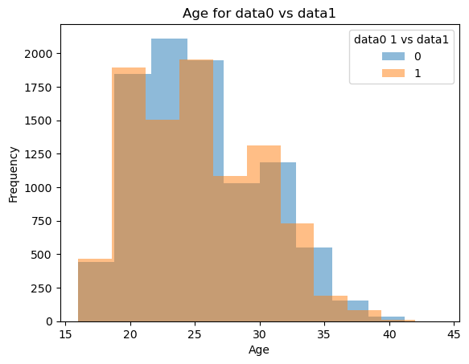

```python
# Write your own code
list_dataset = [data0, data1]

list_unique_dataset = pd.unique(soccer["status"])

for value in list_unique_dataset:
    df = soccer.query("status == @value")
    plt.hist(x = df["Age"], alpha = 0.5)

plt.title("Age for data0 vs data1")
plt.xlabel("Age")
plt.ylabel("Frequency")
plt.legend(labels = list_unique_dataset,
           title  = "data0 1 vs data1")
plt.show()
```